# Untitled

## The Problem of Model Selection

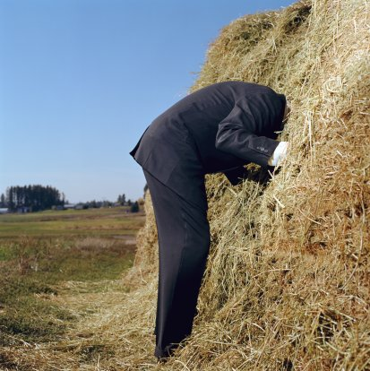

A given data set can conceivably have been generated from infinitely many models. Identifying the true model is like finding a piece of hay in a haystack. Said another way, the model space is massive and the criterion for what constitutes the “best” model is ill-defined.

## The Problem of Model Selection

**Best strategy**: Use domain knowledge to constrain the model space and/or build models that help you answer specific scientific questions.

**Another common strategy:**

1. Pick a criterion for “best”.
2. Decide how to explore the model space.
3. Select “best” model in search area.

**Tread Carefully!!!** The second strategy can lead to myopic analysis, overconfidence, and wrong-headed conclusions.

## What do we mean by “best”?

While we’d like to find the “true” model, in practice we just hope we’re doing a good job at:

1. Prediction
2. Description

## Synthetic example

How smooth should our model be?

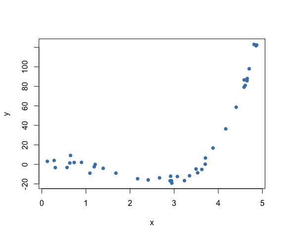

## Four candidates

```r
m1 <- lm(y ~ x)
m2 <- lm(y ~ x + I(x^2))
m3 <- lm(y ~ x + I(x^2) + I(x^3))
m4 <- lm(y ~ x + I(x^2) + I(x^3) + I(x^4))
```

We can add *polynomial* terms to account for non-linear trends.

## Four candidates

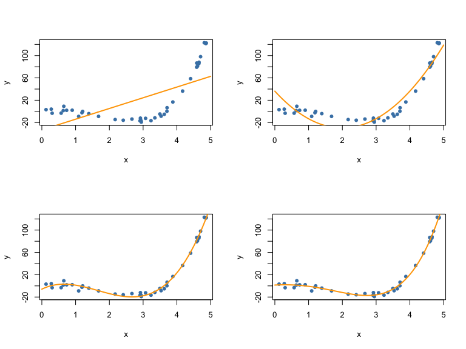

## $R^2$

One way to quantify the explanatory power of a model.

$$R^2 = \frac{SS_{reg}}{SS_{tot}}$$

This captures the proportion of variability in the $y$ explained by our regression model.

## Comparing $R^2$

```r
c(summary(m1)$r.squared,
  summary(m2)$r.squared,
  summary(m3)$r.squared,
  summary(m4)$r.squared)
```

```
## [1] 0.4391650 0.9193636 0.9922563 0.9941130
```

The observed data is best explained by the quartic model. So that’s the best model, right?

## The BEST model!

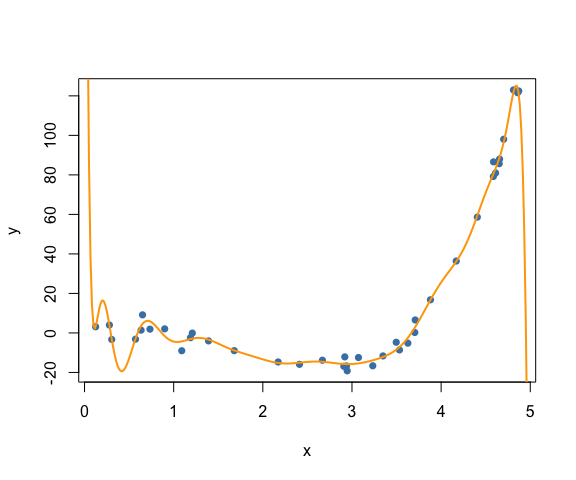

## The BEST model!

```r
mBEST <- lm(y ~ poly(x, 20))
c(summary(m1)$r.squared,
  summary(m2)$r.squared,
  summary(m3)$r.squared,
  summary(m4)$r.squared,
  summary(mBEST)$r.squared)
```

```
## [1] 0.4391650 0.9193636 0.9922563 0.9941130 0.9970739
```

But surely that’s not the best model…

## Three Criteria

1. $R^2$
2. $R^2_{adj}$
3. p-values
- There are many others ($AIC$, $BIC$, $AIC_C$, …).

## $R^2_{adj}$

A measure of explanatory power of model:

$$R^2 = \frac{SS_{reg}}{SS_{tot}} = 1 - \frac{SS_{res}}{SS_{tot}}$$

But like likelihood, it only goes up with added predictors, therefore we add a penalty.

$$R^2_{adj} = 1 - \frac{SS_{res}/(n - (p + 1))}{SS_{tot}/(n - 1)}$$

## $R^2$ vs. $R^2_{adj}$

```r
summary(mBEST)$r.squared
```

```
## [1] 0.9970739
```

```r
summary(mBEST)$adj.r.squared
```

```
## [1] 0.9939938
```

```r
poverty <- read.delim("poverty.txt", header = TRUE)
m1 <- lm(Poverty ~ Graduates, data = poverty)
summary(m1)
```

```
##
## Call:
## lm(formula = Poverty ~ Graduates, data = poverty)
##
## Residuals:
##     Min      1Q  Median      3Q     Max
## -4.1624 -1.2593 -0.2184  0.9611  5.4437
##
## Coefficients:
##             Estimate Std. Error t value Pr(>|t|)
## (Intercept) 64.78097    6.80260   9.523 9.94e-13 ***
## Graduates   -0.62122    0.07902  -7.862 3.11e-10 ***
## ---
## Signif. codes:  0 '***' 0.001 '**' 0.01 '*' 0.05 '.' 0.1 ' ' 1
##
## Residual standard error: 2.082 on 49 degrees of freedom
## Multiple R-squared:  0.5578, Adjusted R-squared:  0.5488
## F-statistic: 61.81 on 1 and 49 DF,  p-value: 3.109e-10
```

```r
poverty$Noise <- rnorm(nrow(poverty))
m2 <- lm(Poverty ~ Graduates + Noise, data = poverty)
summary(m2)
```

```
##
## Call:
## lm(formula = Poverty ~ Graduates + Noise, data = poverty)
##
## Residuals:
##     Min      1Q  Median      3Q     Max
## -4.2872 -1.3136 -0.1214  0.9709  5.4064
##
## Coefficients:
##             Estimate Std. Error t value Pr(>|t|)
## (Intercept) 65.25471    6.82598    9.56 1.08e-12 ***
## Graduates   -0.62594    0.07923   -7.90 3.12e-10 ***
## Noise        0.31654    0.32988    0.96    0.342
## ---
## Signif. codes:  0 '***' 0.001 '**' 0.01 '*' 0.05 '.' 0.1 ' ' 1
##
## Residual standard error: 2.084 on 48 degrees of freedom
## Multiple R-squared:  0.5661, Adjusted R-squared:  0.548
## F-statistic: 31.31 on 2 and 48 DF,  p-value: 1.981e-09
```